# Titanic

Winston Saunders

December 31, 2014

### Introduction

```r
        training <- read.csv("train.csv", na.strings=c("NA", ""))
        testing <- read.csv("test.csv", na.strings=c("NA", ""))
```

## First model

Base first model on Sex and Age per tutorial. Since there are many NA’s in the data we replace those with the mean ages for male or females.

The model is trained with a *Random Forest*.

The mean male age is 30.7 years and the mean female age is 27.9 years. Here is a snapshot of the cleaned data. Note the fractional year on substituted values.

```r
training[1:6,c("Survived", "Age", "Sex")]
```

```
##   Survived      Age    Sex
## 1        0 22.00000   male
## 2        1 38.00000 female
## 3        1 26.00000 female
## 4        1 35.00000 female
## 5        0 35.00000   male
## 6        0 30.72664   male
```

The first model looks at the following function

```r
        modelfunction<-Survived~Age+Sex
```

Here is the confusion table

```r
conf$table
```

```
##           Reference
## Prediction   0   1
##          0 105   8
##          1  38  27
```

The accuracy is 74.2%.

### Second Approach - nested feature modeling

Age data substitution appears to be a critical factor in model accuracy. Age plays a strong role in survival. Since there are a lorge number of NAs in the age data which need to be modeled, let’s see if the method of directly substituting mean age can be improved.

Since Passenger class affects survival it’s logical to look for dependency there.

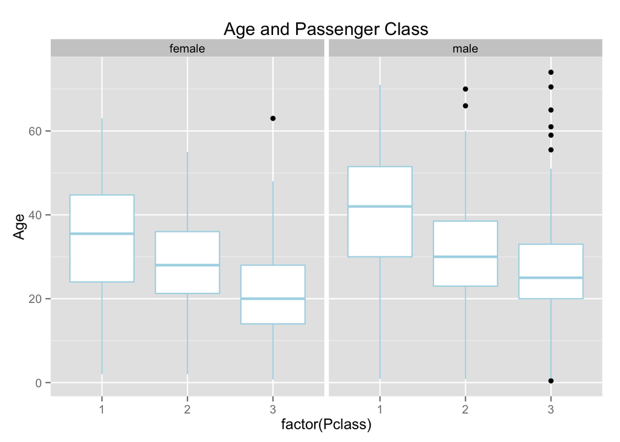

The age model is set up as follows

```r
        agemodel<-glm(Age~Pclass+Sex, data=trainfull)
```

RMSE of the age-fit is 13.7 versus of using the mean 15.

Here is a plot of the fitted age versus actual age. Note some values have been substituted…

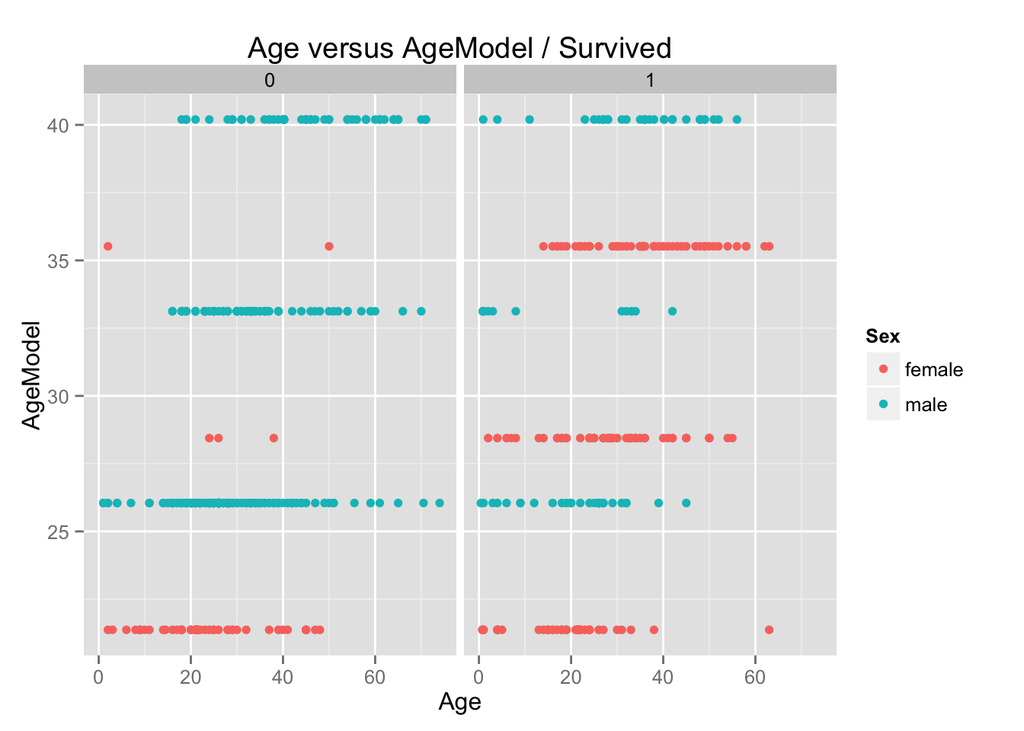

The survivial model function is:

```r
        modelfunction <- Survived~Age+Sex+Pclass
```

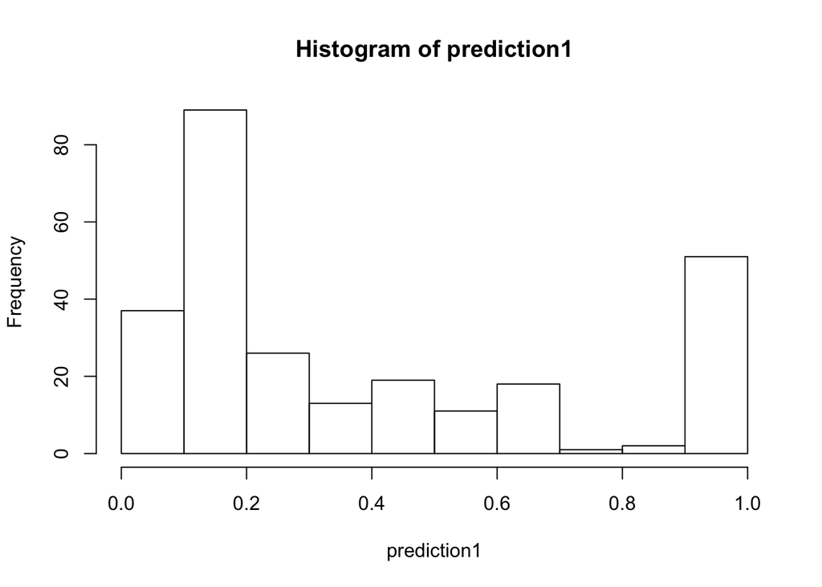

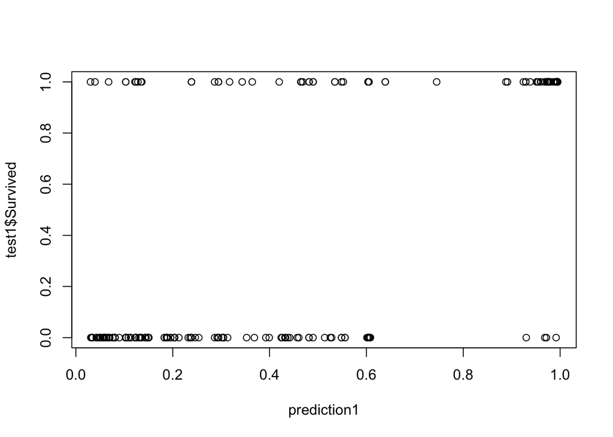

Resulting in the following confusion matrix

```
##           Reference
## Prediction   0   1
##          0 172   4
##          1  41  50
```

The accuracy is 83.15 versus earlier 74.16%.

### Model4

Let’s try seperate models for men and women.

Segregate

```r
        train1.m<-train1[train1$Sex=="male",]
        train1.f<-train1[train1$Sex=="female",]

        test1.m<-test1[test1$Sex=="male",]
        test1.f<-test1[test1$Sex=="female",]
```

```r
        trainfull.f<-train1.f[is.na(train1.f$Age)==FALSE, ]
```

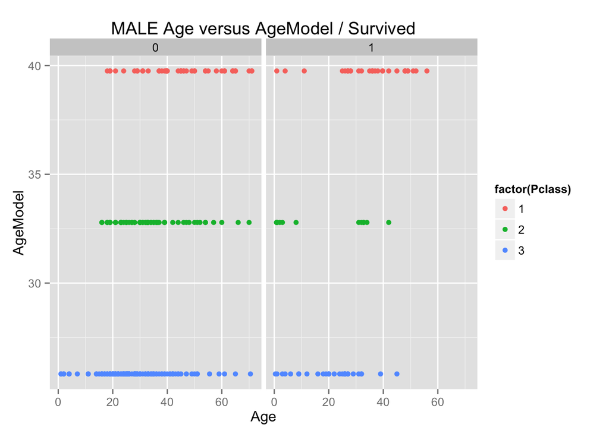

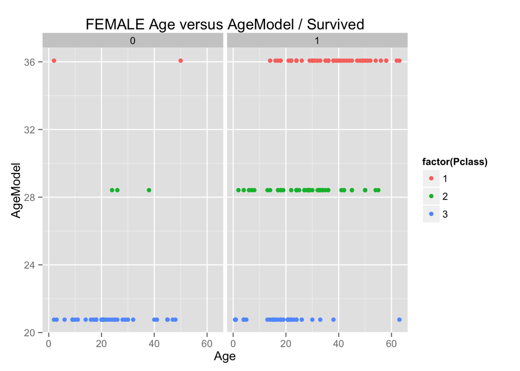

Based on this plot there is a substantial population of “young” survivors who have helpers.

```r
        modelfunction <- Survived~AgeModel+Pclass+Sex
```

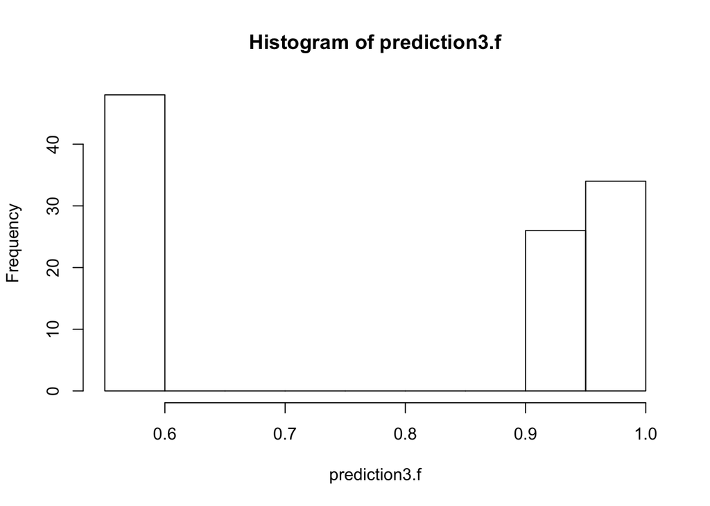

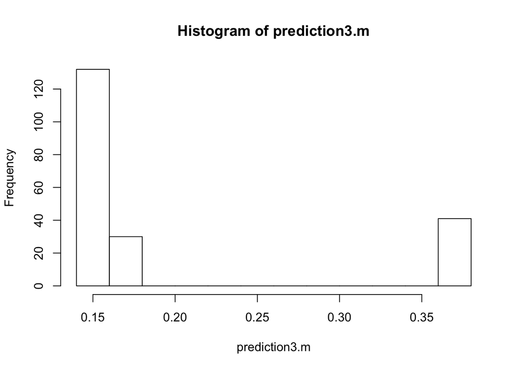

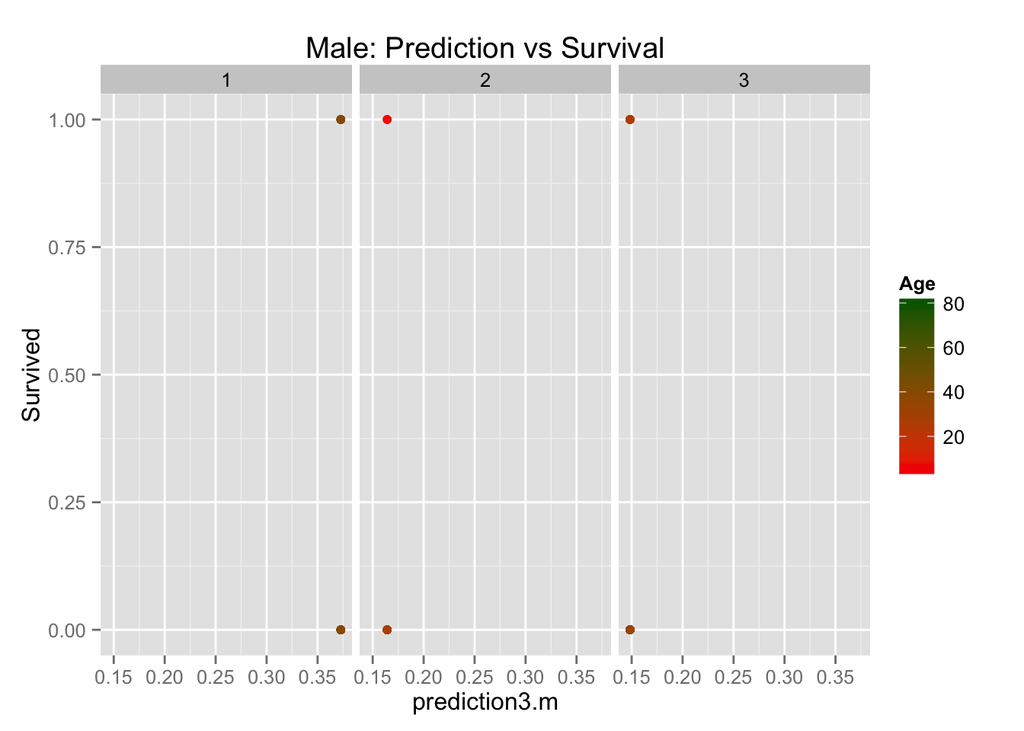

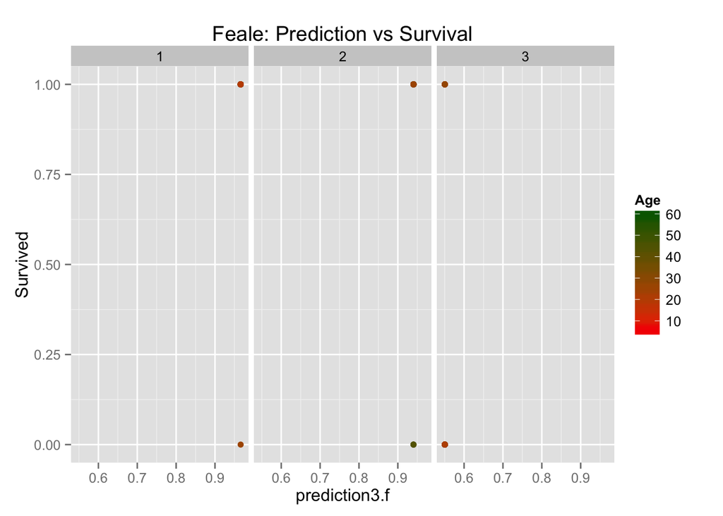

Here is the confusion matrix

```r
conf3.m$table
```

```
##           Reference
## Prediction   0   1
##          0 143  26
##          1  19  15
```

Here is the confusion matrix

```r
conf3.f$table
```

```
##           Reference
## Prediction  0  1
##          0 29  4
##          1 19 56
```

The accuracy is 77.83 for males and 78.7for females compares to the earlier 83.15%.

## Attempt 4

I tried an “Old Fart” model (identify old men, some of whom seemed to have survived). But that did not impove accuracy.

The age model is set up as follows

```r
        agemodel<-glm(Age~Pclass+Sex, data=trainfull)
```

It slightly improves the RMSE of a fit is 13.7 versus of using the mean 15. An improvement. So I’l use that to fill in blanks.

Another way to look at this data is by buckets

```r
        train1$OldFarts<- -1
        train1$OldFarts[train1$Sex=="male"&train1$Age>60] <- 1

        test1$OldFarts<- -1
        test1$OldFarts[test1$Sex=="male"&test1$Age>60] <- 1
```

```r
        modelfunction <- Survived~Age+Pclass+OldFarts+Sex
```

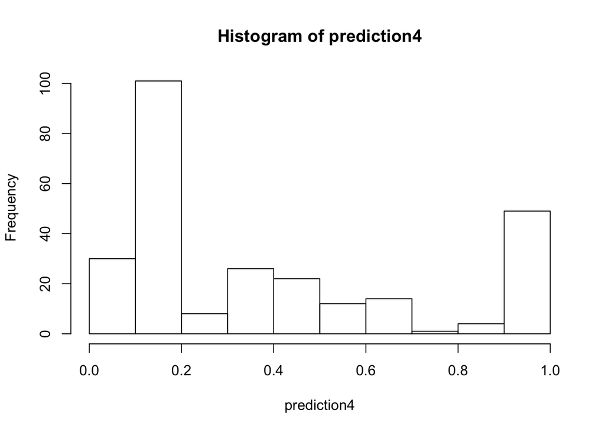

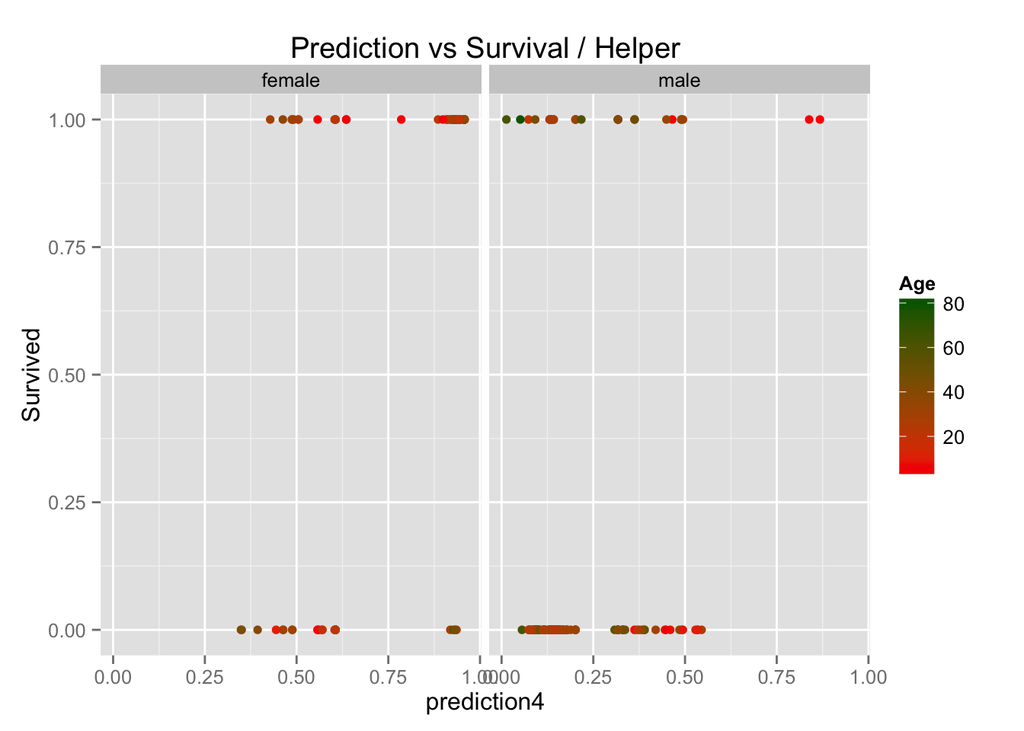

Here is the confusion matrix

```
##           Reference
## Prediction   0   1
##          0 172   4
##          1  42  49
```

The accuracy is 82.77 compares to earlier 83.15%.